# M9/Final

Git In

12/11/2021

## Introduction

Trans-Gulf migrants (TGMs) travel long distances to forage and breed. These birds migrate from Central and South America every spring to more temperate regions between Texas and Florida. Their time of arrival to the breeding grounds have differing tradeoffs and can affect the fitness of the migrants. Early arrivals correlate with higher chances of mating and breeding while later arrivals benefit from surplus food availiblility (Smith and Moore (2005)). One study that studied migration patterns from 1828-2010, found a uniform trend of earlier arrivals correlated with higher temperatures from 1978 to 2010 (Kolářová et al. (2017)).

In the face of climate change, populations of TGMs may decline if there is a failure to shift arrival dates in response to warmer temperatures (Both et al. (2006)).

With an increase in species conservation among the public in the recent decades, many online programs are available for researchers to access and study. The Cornell Laboratory of Ornithology and the National Audubon Society have established the program eBird, a compilation of over a hundred million bird observations from thousands of contributors.

## Methods

In order to study the effect of local weather conditions on the arrival time of TGMs in Massachusetts, the meteorological data from Mobile AL, Charlotte NC, and Boston MA were acquired from NOAA’s National Climatic Data Center’s API to examine five species of birds (*Hylocichla mustelina, Archilochus colubris, Seiurus aurocapilla, Progne subis*, and *Icterus galbula*) from eBird.

The arrival time for each species was considered to be the julian day when 25% of birds had arrived in a given year according to a logistic model. The birds were estimated to be in Mobile and Charlotte 10 and 5 days before the arrival in Boston, respectively. Using this, a rolling mean of temperature and wind data was taken over a two week period surrounding the dates that the birds were estimated to be passing through each location.

Linear Mixed-Effect Modeling was used to evaluate the effect of multiple covariates and their individual and combined effect on arrival date. We ranked our nested models using the dredge() function in order to determine what was included in our best fit model. We then performed an ANOVA analysis on the best fit model to determine which variables had a significant effect on arrival date.

We also performed ANOVA analysis on maximum temperature, minimum temperature, and wind using a single day sample and two week average to determine the effect these variables have on arrival date.

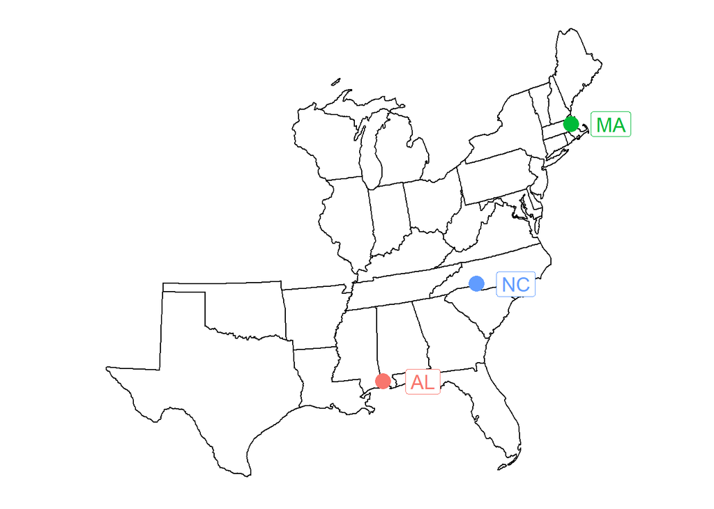

Figure 1: Map of the weather stations used along the migration route

Weather data from three stations, Mobile AL, Charlotte NC, and Boston MA were used to estimate weather conditions along the migration route to Massachusetts. Weather parameters assessed include maximum temperature, minimum temperature, and the wind vector.

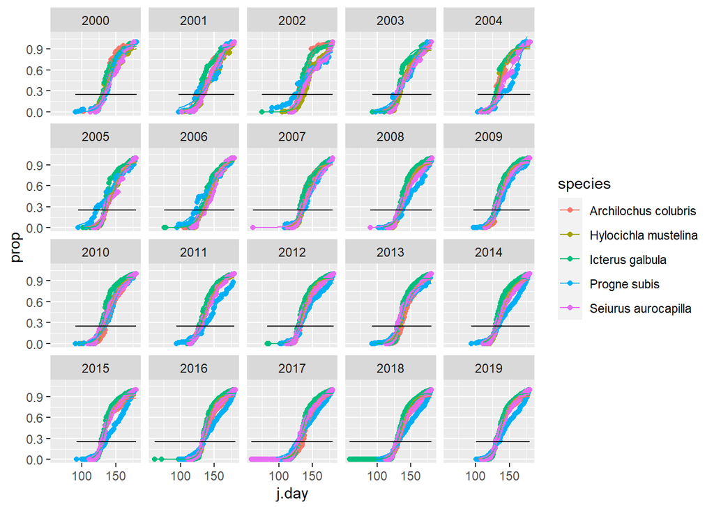

Figure 2: logistic models representing the proportion of birds of each species arriving in Massachusetts each year.

The proportion of birds arriving in Massachusetts in a given year was modelled using a logistic curve.

Our ANOVA analysis revealed a significant relationship between minimum temperature as well as the interaction between maximum temperature and wind vector on a single day and the date of arrival.

ANOVA Analysis on Arrival Date and Single Day Sample weather data

| term | statistic | df | p.value |
| --- | --- | --- | --- |
| tmin | 7.137703 | 1 | 0.0075480 |
| tmax | 2.218337 | 1 | 0.1363799 |
| wvec | 3.518558 | 1 | 0.0606852 |
| tmin:tmax | 1.191680 | 1 | 0.2749909 |
| tmin:wvec | 2.544127 | 1 | 0.1107051 |
| tmax:wvec | 3.891512 | 1 | 0.0485307 |
| tmin:tmax:wvec | 1.477885 | 1 | 0.2241057 |

Our ANOVA analysis on the two-week average weather data revealed a significant relationship between the following variables and arrival date: minimum temperature, wind vector, and the interaction between minimum and maximum temperature.

ANOVA Analysis on Arrival Date and Two-week average weather data

| term | statistic | df | p.value |
| --- | --- | --- | --- |
| wk.tmin | 9.5947582 | 1 | 0.0019513 |
| wk.tmax | 1.9737948 | 1 | 0.1600456 |
| wk.wvec | 12.2289183 | 1 | 0.0004705 |
| wk.tmin:wk.tmax | 7.8431811 | 1 | 0.0051013 |
| wk.tmin:wk.wvec | 0.1045737 | 1 | 0.7464085 |
| wk.tmax:wk.wvec | 0.1702168 | 1 | 0.6799192 |
| wk.tmin:wk.tmax:wk.wvec | 0.1776189 | 1 | 0.6734275 |

Our analysis using the dredge() function returned NA results for the interactions models. Therefore, the best fit model was one that included minimum temperature, maximum temperature, and wind vector. This model was then analyzed using ANOVA and it was found that minimum temperature and wind vector were significant predictors of arrival date.

Fit values for nested models of the most complicated lme model

|  | (Intercept) | wk.tmax | wk.tmin | wk.wvec | wk.tmax:wk.tmin | wk.tmax:wk.wvec | wk.tmin:wk.wvec | wk.tmax:wk.tmin:wk.wvec | df | logLik | AICc | delta | weight |
| --- | --- | --- | --- | --- | --- | --- | --- | --- | --- | --- | --- | --- | --- |
| 1 | 127.0083 | -0.0033496 | 0.0512740 | -0.0793747 | NA | NA | NA | NA | 6 | -757.7684 | 1527.824 | 0.00000 | 0.9976372161 |
| 2 | 118.8755 | 0.0255546 | 0.1655764 | -0.0682935 | -0.0004253 | NA | NA | NA | 7 | -763.1525 | 1540.689 | 12.86495 | 0.0016046680 |
| 5 | 127.0031 | -0.0037143 | 0.0521271 | -0.0739010 | NA | NA | -4.85e-05 | NA | 7 | -764.3710 | 1543.126 | 15.30200 | 0.0004744450 |
| 3 | 127.0298 | -0.0029408 | 0.0501061 | -0.0919693 | NA | 5.85e-05 | NA | NA | 7 | -764.8853 | 1544.154 | 16.33066 | 0.0002836709 |

ANOVA Analysis on Best Fit Model

| term | statistic | df | p.value |
| --- | --- | --- | --- |
| wk.tmin | 15.4113455 | 1 | 0.0000865 |
| wk.tmax | 0.1088388 | 1 | 0.7414700 |
| wk.wvec | 18.9006595 | 1 | 0.0000138 |

## Author Contributions

The introduction was written by Belinda Wang and Steven LaFever. Methods were written by Sarah Figueroa and Belinda Wang. Results were added by Sarah Figueroa. The discussion was written by Emma Oss.

## References

Both, Christiaan, Sandra Bouwhuis, CM Lessells, and Marcel E Visser. 2006. “Climate Change and Population Declines in a Long-Distance Migratory Bird.” *Nature* 441 (7089): 81–83.

Burnside, Robert, Daniel Salliss, and Nigel J Collar. 2021. “Birds Use Individually Consistent Temperature Cues to Time Their Migration Departure.” *Proceedings of the National Academy of Sciences of the United States of America* 118 (28).

Kolářová, Eva, Michael Matiu, Annette Menzel, Jiřı́ Nekovář, Petr Lumpe, and Peter Adamı́k. 2017. “Changes in Spring Arrival Dates and Temperature Sensitivity of Migratory Birds over Two Centuries.” *International Journal of Biometeorology* 61 (7): 1279–89.

Marra, Peter, Charles Francis, Robert Mulvihill, and Frank Moore. 2004. “The Influence of Climate on the Timing and Rate of Spring Bird Migration.” *Oecologica* 142: 307–15.

Smith, Robert J, and Frank R Moore. 2005. “Arrival Timing and Seasonal Reproductive Performance in a Long-Distance Migratory Landbird.” *Behavioral Ecology and Sociobiology* 57 (3): 231–39.